# Prosper Loan Data Analysis

## Introduction

## Wrangling the data

We will start with cleaning the dataset, dropping some unneccessary and irrelevant data, filling some missing data with our caculated algorithm, then finally analyzing and visualizing it.

This data frame, in general, is having some issues that need to be solved.

- At first, there are many variables that are not important or we don't need due to the limit of our analysis. Getting rid of them will make the dataset easier to read and understand.
- Secondly, there are too many cells that have Null value, abnormal value and improper types noticed in some columns. Some of them can be calculated/inputted with algorithm. The more comprehensive the dataframe has, the more easier the analysis task is.

## Visualizing the data

### Loan Purpose by Category

Loan purpose is an important index as it can easily tell us the validity of clients' request when they start applying to the loan. When a loan purpose doesn't fit the bank policy, client can be rejected form the beginning process.

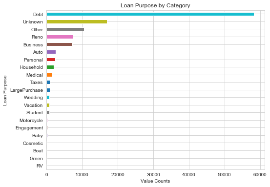

```python
# using Horizontal bar
listing_category.plot.barh(figsize= (8,6))
plt.xlabel('Value Counts', fontsize=10)
plt.ylabel('Loan Purpose', fontsize=10)
plt.title('Loan Purpose by Category')
plt.show()
```

### Credit Score by Prosper Score

Credit Score has a big impact on the acceptance rate and borrowing rate of the loan. Prosper Loan Company, on the other hand, has developed their own score to rate their clients. We will see how comparative these two index are when they are placed next to each other.

```
(400, 1000)
```

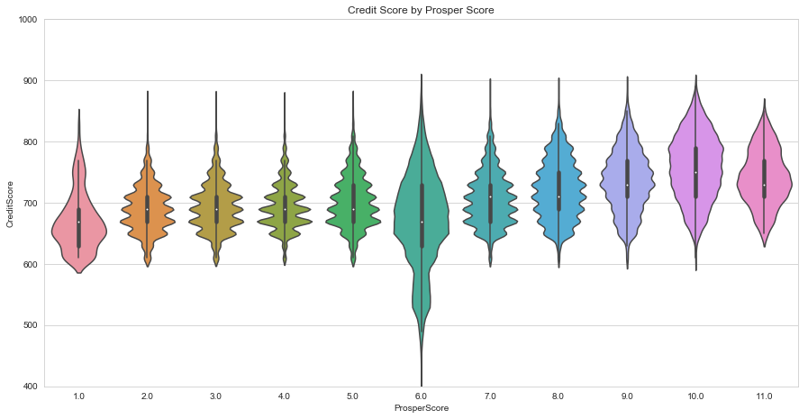

```python
ax = sns.violinplot(x= 'ProsperScore', y ='CreditScore', data = df, scale ='width' )
ax.set_title("Credit Score by Prosper Score")
plt.ylim(400,1000)
```

### Employment Status of the Borrower

Employement status is another category that show the financial status of debtor. The higher chance they are employed and having a full-time job, the higher chance they have their income to pay for their loan installment.

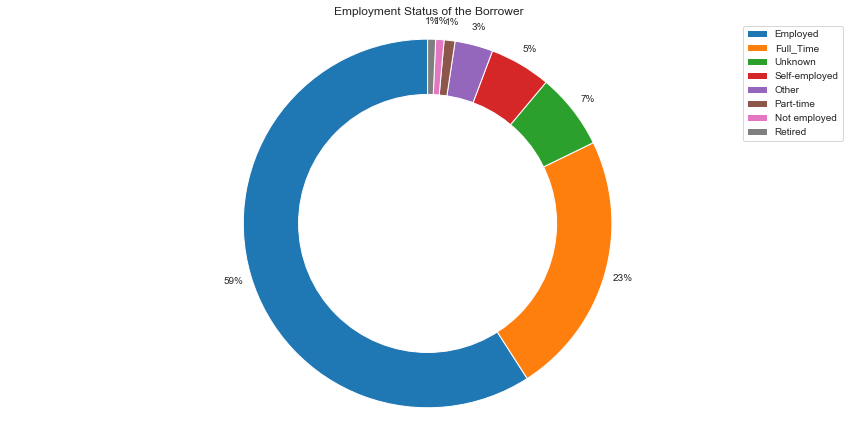

```python
labels = ['Employed','Full_Time', 'Unknown', 'Self-employed', 'Other', 'Part-time', 'Not employed', 'Retired']
plt.pie(df['EmploymentStatus'].value_counts(),autopct='%1.0f%%', startangle=90, pctdistance=1.1, labeldistance=1.3)
#creating a donut pie
centre_circle = plt.Circle((0,0),0.70,fc='white')
fig = plt.gcf()
fig.gca().add_artist(centre_circle)

#Adding title and legend
plt.title('Employment Status of the Borrower')
plt.legend(labels=labels)

# Equal aspect ratio ensures that pie is drawn as a circle
#plt.tight_layout()
plt.axis('equal')
plt.show()
```